# Spatial Accessibility to Healthcare

- Show All Code
- Hide All Code
- View Source

Spatial Epidemiology — Lehigh University

Author

Eric Delmelle

Published

January 1, 2026

## Learning Objectives

By the end of this lecture, you should:

1. Recognize different ways to measure spatial accessibility 2 Understand that distance and travel time influence access to services
2. Interpret a simple example of an accessibility measure
3. Identify areas that may be underserved

## Part 1 — Conceptual Background

### What is accessibility?

Accessibility is not the same as proximity. A hospital 3 miles away means something entirely different to a car-owning professional with flexible hours versus an elderly patient relying on fixed-route transit. Accessibility formalizes the relationship between **who needs care**, **where services are**, and **the friction of traveling between them**.

The classic formulation distinguishes three components:

| Component | Question it answers | Example measure |
| --- | --- | --- |
| **Availability** | How much supply is there? | Physicians per 10,000 population |
| **Proximity** | How far is the nearest facility? | Distance to closest hospital (km) |
| **Accessibility** | How much supply can I reach, given distance friction and competition? | 2SFCA score |

**Key Insight**

Patients do **not** always go to the closest health center. They may prefer a provider with a specific specialty, one accepted by their insurer, or one reachable by transit. This behavioral reality motivates **probabilistic** catchment area models over simple nearest-facility approaches.

### A typology of accessibility measures

**1. Simple (primitive) methods**

- *Provider-to-population ratio (PPR)*: total supply / total population. Ignores geography entirely.
- *Distance to nearest facility*: geographically explicit, but ignores supply quantity and competition.
- *Container method*: counts facilities within an administrative boundary. Subject to severe edge effects.

**2. Gravity models**

Inspired by Newton’s law, the gravitational potential at location $i$ is:

$$A_i = \sum_j \frac{S_j}{d_{ij}^\beta}$$

where $S_j$ is supply at $j$, $d_{ij}$ is travel cost, and $\beta$ controls distance sensitivity. Gravity models capture **cumulative access** to all facilities, weighted by distance — but they do not account for competition among demand locations.

**3. Floating Catchment Area (FCA) methods**

FCA methods solve the competition problem by computing **provider-to-population ratios within catchments that “float”** over each supply and demand location. The 2SFCA (Luo & Wang 2003) is the most widely implemented variant.

**4. Cumulative opportunities**

Counts the number of opportunities (facilities, jobs, etc.) reachable within a **travel time threshold** — e.g., how many hospitals can be reached in 30 minutes by transit? Simple and interpretable, and especially powerful with real transport network data via the `r5r` package.

## Part 2 — Distance, Travel Time, and Impedance

Before computing any accessibility measure, we need a **cost matrix** between demand and supply locations.

### Straight-line (Euclidean) distance

Fastest to compute, but unrealistic in most contexts.

```r
library(sf)
library(dplyr)

# Two example points
pts <- st_as_sf(
  data.frame(
    name = c("Allentown", "Bethlehem"),
    lon  = c(-75.490, -75.370),
    lat  = c(40.608, 40.617)
  ),
  coords = c("lon", "lat"), crs = 4326
)

pts_proj <- st_transform(pts, 32618)  # UTM zone 18N (meters)
d_euclidean <- st_distance(pts_proj)
cat("Straight-line distance:", round(as.numeric(d_euclidean[1, 2]) / 1000, 2), "km\n")
```

```
Straight-line distance: 10.2 km
```

### Network travel time via `gmapsdistance`

For real-world analyses, **road network travel time** is far more meaningful. The `gmapsdistance` package queries the Google Maps Distance Matrix API.

```r
# Requires a valid Google Maps API key stored in .Renviron
# NEVER hardcode your key in a shared script
library(gmapsdistance)

set.api.key(Sys.getenv("GOOGLE_API_KEY"))

# Single pair: driving time
result <- gmapsdistance(
  origin      = "Allentown PA",
  destination = "Bethlehem PA",
  mode        = "driving"
)
cat("Travel time:", round(result$Time / 60, 1), "minutes\n")
cat("Distance:", round(result$Distance / 1000, 1), "km\n")

# Distance matrix: 4 cities × 4 cities (all modes)
cities <- c("Allentown PA", "Bethlehem PA", "Easton PA", "Emmaus PA")
mat <- gmapsdistance(
  origin      = cities,
  destination = cities,
  mode        = "driving"
)

# Convert seconds to minutes
round(mat$Time / 60, 1)

# With a specific departure time (transit schedules change by time of day!)
mat_transit <- gmapsdistance(
  origin      = cities,
  destination = cities,
  mode        = "transit",
  dep_date    = "2026-03-16",
  dep_time    = "08:00:00",
  key         = Sys.getenv("GOOGLE_API_KEY")
)
round(mat_transit$Time / 60, 1)
```

**API Key Security**

Never embed a real API key in a Quarto document or R script that will be shared or published. Always use `Sys.getenv("GOOGLE_API_KEY")` and store the key in your `.Renviron` file. Google Maps API calls are **rate-limited and billed** beyond the free tier.

**Free Alternatives**

- **`osrm` package**: OpenStreetMap routing — free, no API key, very accurate road-network distances
- **`r5r` package**: Multimodal routing (walk + transit + bike + car) using GTFS + OSM — ideal for transit equity studies (see Part 5)
- **`dodgr` package**: Extremely fast street network distances in R

### Why travel time changes everything

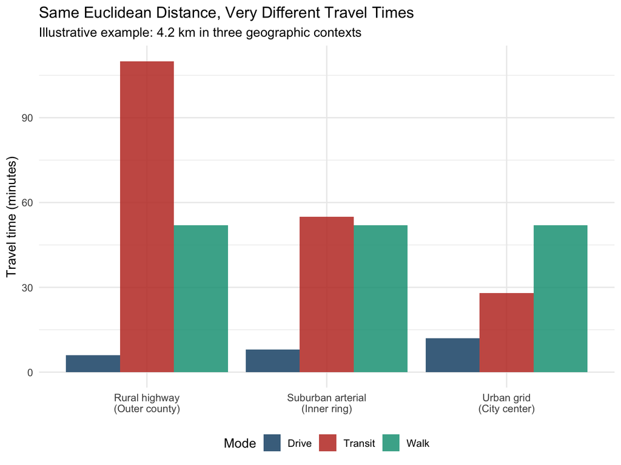

```r
library(ggplot2)

examples <- data.frame(
  Location = c("Urban grid\n(City center)",
               "Suburban arterial\n(Inner ring)",
               "Rural highway\n(Outer county)"),
  Euclidean_km = c(4.2, 4.2, 4.2),
  Drive_min    = c(12, 8, 6),
  Transit_min  = c(28, 55, 110),
  Walk_min     = c(52, 52, 52)
)

tidyr::pivot_longer(examples,
                    cols = c(Drive_min, Transit_min, Walk_min),
                    names_to = "Mode", values_to = "Minutes") |>
  dplyr::mutate(Mode = gsub("_min", "", Mode)) |>
  ggplot(aes(x = Location, y = Minutes, fill = Mode)) +
  geom_col(position = "dodge", alpha = 0.85) +
  scale_fill_manual(values = c("#1a5276", "#c0392b", "#16a085")) +
  labs(
    title = "Same Euclidean Distance, Very Different Travel Times",
    subtitle = "Illustrative example: 4.2 km in three geographic contexts",
    x = NULL, y = "Travel time (minutes)", fill = "Mode"
  ) +
  theme_minimal(base_size = 12) +
  theme(legend.position = "bottom")
```

## Part 3 — Gravity Models and the SpatialPosition Package

Before 2SFCA, **gravity-based accessibility** was the workhorse of spatial interaction modeling. The `SpatialPosition` package (Commenges & Giraud) implements the **Stewart**, **Reilly**, and **Huff** models.

### Setup and data

We use North Carolina county data (built into the `sf` package), with simulated hospital locations based on major NC cities. No API key required.

```r
library(sf)
library(dplyr)
library(tmap)
library(SpatialPosition)
library(RColorBrewer)

tmap_mode("plot")

# NC counties
nc <- st_read(system.file("shape/nc.shp", package = "sf"), quiet = TRUE)
nc <- st_transform(nc, crs = 32617)  # UTM zone 17N

# Simulated hospitals at approximate major NC city locations
hospitals_df <- data.frame(
  name = c("Charlotte Medical", "Raleigh General", "Greensboro Health",
           "Durham Regional", "Winston-Salem Hosp", "Fayetteville Med",
           "Asheville Mountain", "Wilmington Coast", "High Point Hosp",
           "Rocky Mount Reg"),
  lon  = c(-80.843, -78.644, -79.792, -78.899, -80.244,
           -78.878, -82.551, -77.946, -79.994, -77.789),
  lat  = c( 35.227,  35.779,  36.073,  35.994,  36.099,
            35.053,  35.565,  34.226,  35.955,  35.938),
  beds = c(874, 620, 480, 550, 510, 390, 290, 345, 260, 220)
)

hospitals_sf <- st_as_sf(hospitals_df, coords = c("lon", "lat"), crs = 4326) |>
  st_transform(32617)

# County centroids as demand points; use birth counts as population proxy
nc_centroids       <- st_centroid(nc)
nc_centroids$pop   <- nc$BIR74 + nc$BIR79
nc$pop             <- nc_centroids$pop   # also attach to nc polygon layer

cat("Counties:", nrow(nc), "| Hospitals:", nrow(hospitals_sf), "\n")
```

```
Counties: 100 | Hospitals: 10
```

```r
cat("Total population proxy:", format(sum(nc_centroids$pop), big.mark = ","), "\n")
```

```
Total population proxy: 752,354
```

```r
cat("Total hospital beds:", sum(hospitals_df$beds), "\n")
```

```
Total hospital beds: 4539
```

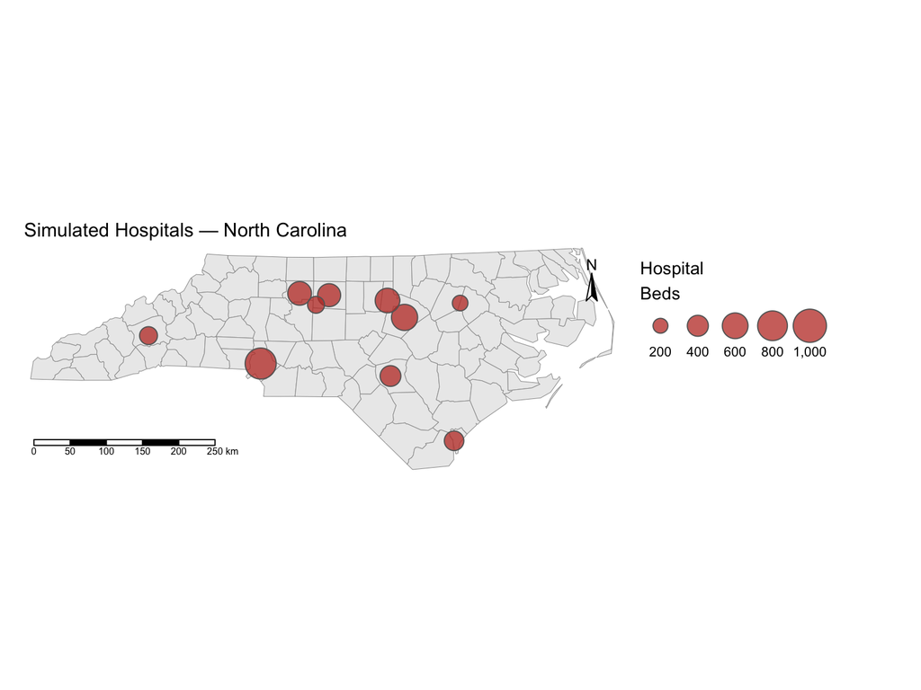

```r
tm_shape(nc) +
  tm_fill(col = "grey92") +
  tm_borders(col = "grey60", lwd = 0.5) +
  tm_shape(hospitals_sf) +
  tm_symbols(
    size  = "beds",
    col   = "#c0392b",
    alpha = 0.75,
    scale = 1.8,
    title.size = "Hospital\nBeds"
  ) +
  tm_layout(
    main.title = "Simulated Hospitals — North Carolina",
    main.title.size = 1.0,
    legend.outside = TRUE,
    legend.outside.position = "right",
    frame = FALSE
  ) +
  tm_scale_bar(position = c("left", "bottom")) +
  tm_compass(position = c("right", "top"), size = 1.5)
```

### Stewart potential (gravitational accessibility)

The Stewart model computes the **potential** at each location — the sum of all supply masses, weighted by a negative distance function. It answers: *“How much hospital capacity can I ‘feel’ from where I am?”*

$$A_i = \sum_{j=1}^{n} S_j \cdot f(d_{ij})$$

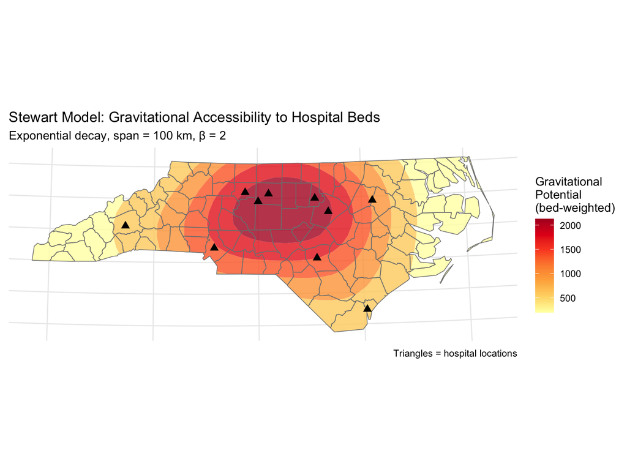

```r
# Key: do NOT pass unknownpts when you intend to call isopoly() afterwards.
# When unknownpts is omitted, stewart() generates its own regular grid over
# the mask, which is what isopoly() (via interp::interp) requires.
# Passing nc_centroids produces irregular point output that crashes isopoly().
#
# resolution = 20000 m (20 km) is safe for NC's ~800 × 200 km extent.
# Finer values (< 15 km) push the interpolation grid past interp's limits.
potentials <- stewart(
  knownpts   = hospitals_sf,
  varname    = "beds",
  typefct    = "exponential",
  span       = 100000,   # 100 km (meters, UTM CRS)
  beta       = 2,
  resolution = 20000,    # 20 km grid — stable across all machines
  mask       = nc
)

isopot <- isopoly(x = potentials, mask = nc, nclass = 6, returnclass = "sf")

ggplot() +
  geom_sf(data = isopot, aes(fill = center), alpha = 0.80, color = NA) +
  geom_sf(data = nc, fill = NA, color = "grey50", linewidth = 0.3) +
  geom_sf(data = hospitals_sf, color = "black", size = 2.5, shape = 17) +
  scale_fill_distiller(
    palette   = "YlOrRd",
    direction = 1,
    name      = "Gravitational\nPotential\n(bed-weighted)"
  ) +
  labs(
    title    = "Stewart Model: Gravitational Accessibility to Hospital Beds",
    subtitle = "Exponential decay, span = 100 km, β = 2",
    caption  = "Triangles = hospital locations"
  ) +
  theme_minimal(base_size = 11) +
  theme(axis.text = element_blank(), axis.ticks = element_blank())
```

### Reilly model: deterministic catchment areas

The **Reilly model** assigns each location to the hospital with the greatest attraction force — creating non-overlapping catchment zones analogous to Voronoi regions, but weighted by supply mass.

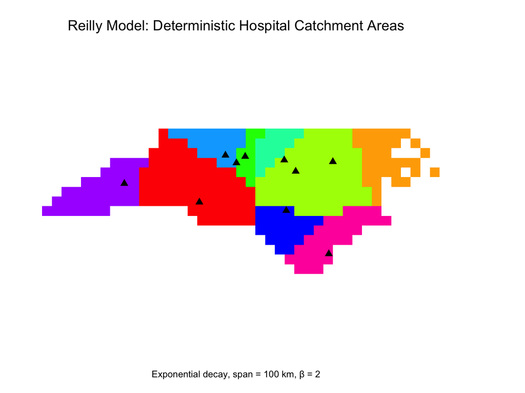

```r
catchReilly <- reilly(
  knownpts    = hospitals_sf,
  varname     = "beds",
  typefct     = "exponential",
  span        = 100000,
  beta        = 2,
  resolution  = 20000,   # 20 km — consistent with Stewart
  mask        = nc,
  returnclass = "sf"
)

rasterCatch <- rasterReilly(x = catchReilly, mask = nc)

par(mar = c(3, 1, 3, 1))
plotReilly(x = rasterCatch)
plot(st_geometry(hospitals_sf), pch = 17, col = "black", add = TRUE, cex = 1.2)
mtext("Reilly Model: Deterministic Hospital Catchment Areas",
      side = 3, cex = 1.3, line = 0.5)
mtext("Exponential decay, span = 100 km, β = 2", side = 1, line = 1, cex = 0.85)
```

### Huff model: probabilistic catchment areas

The **Huff model** expresses attraction as a *probability* — for each location, the probability of choosing hospital $j$ over all alternatives. This produces overlapping, fuzzy catchments that better reflect real patient behavior.

$$P_{ij} = \frac{S_j \cdot f(d_{ij})}{\displaystyle\sum_k S_k \cdot f(d_{ik})}$$

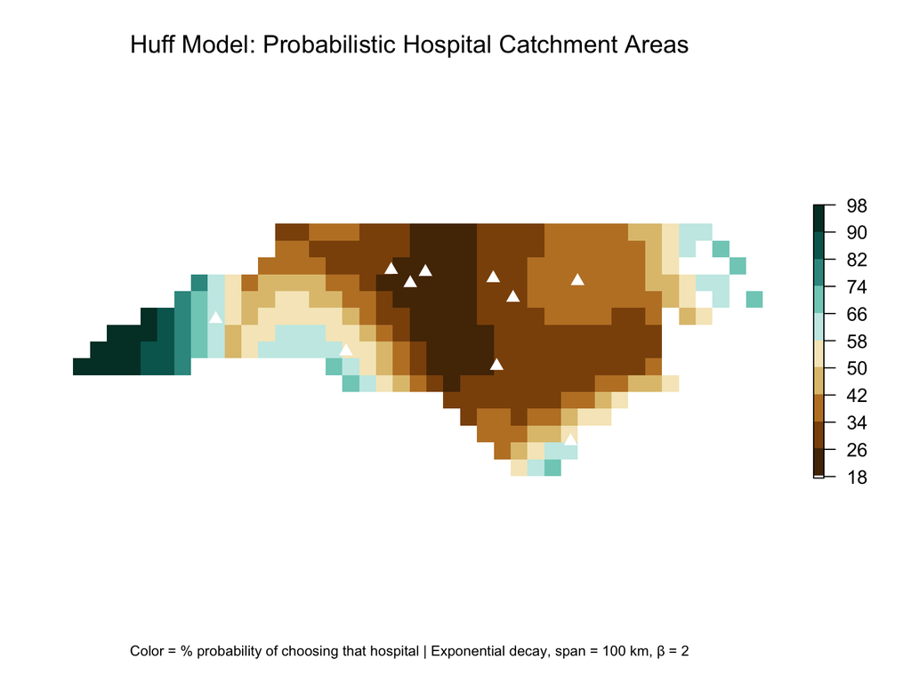

```r
catchHuff <- huff(
  knownpts    = hospitals_sf,
  varname     = "beds",
  typefct     = "exponential",
  span        = 100000,
  beta        = 2,
  resolution  = 20000,   # 20 km — consistent with Stewart
  mask        = nc,
  returnclass = "sf"
)

rasterHuff_obj <- rasterHuff(x = catchHuff, mask = nc)

par(mar = c(3, 1, 3, 1))
plotHuff(x = rasterHuff_obj)
plot(st_geometry(hospitals_sf), pch = 17, col = "white", add = TRUE, cex = 1.2)
mtext("Huff Model: Probabilistic Hospital Catchment Areas",
      side = 3, cex = 1.3, line = 0.5)
mtext("Color = % probability of choosing that hospital | Exponential decay, span = 100 km, β = 2",
      side = 1, line = 1, cex = 0.75)
```

**Reilly vs. Huff: When to Use Which**

Use **Reilly** when you need to assign each location to a single “primary” facility — for zoning, service area planning, or administrative delineation.

Use **Huff** when you want to model realistic patient behavior, where individuals may use multiple facilities. Huff probabilities multiplied by population counts yield **expected patient volumes** at each facility — a powerful tool for facility sizing and investment planning.

## Part 4 — Two-Step Floating Catchment Area (2SFCA)

The 2SFCA method addresses a key limitation of gravity models: it explicitly accounts for **competition** among patients for the same provider.

### Mathematical formulation

**Step 1** — For each provider $j$, compute the provider-to-population ratio within its catchment:

$$R_j = \frac{S_j}{\displaystyle\sum_{k \,:\, d_{kj} \leq d_0} P_k \cdot W(d_{kj})}$$

**Step 2** — For each demand location $i$, sum all provider ratios it can reach:

$$A_i = \sum_{j \,:\, d_{ij} \leq d_0} R_j \cdot W(d_{ij})$$

$A_i$ is the **accessibility score**: spatially adjusted beds (or physicians) per unit of weighted population. Higher = better access.

### Distance decay functions

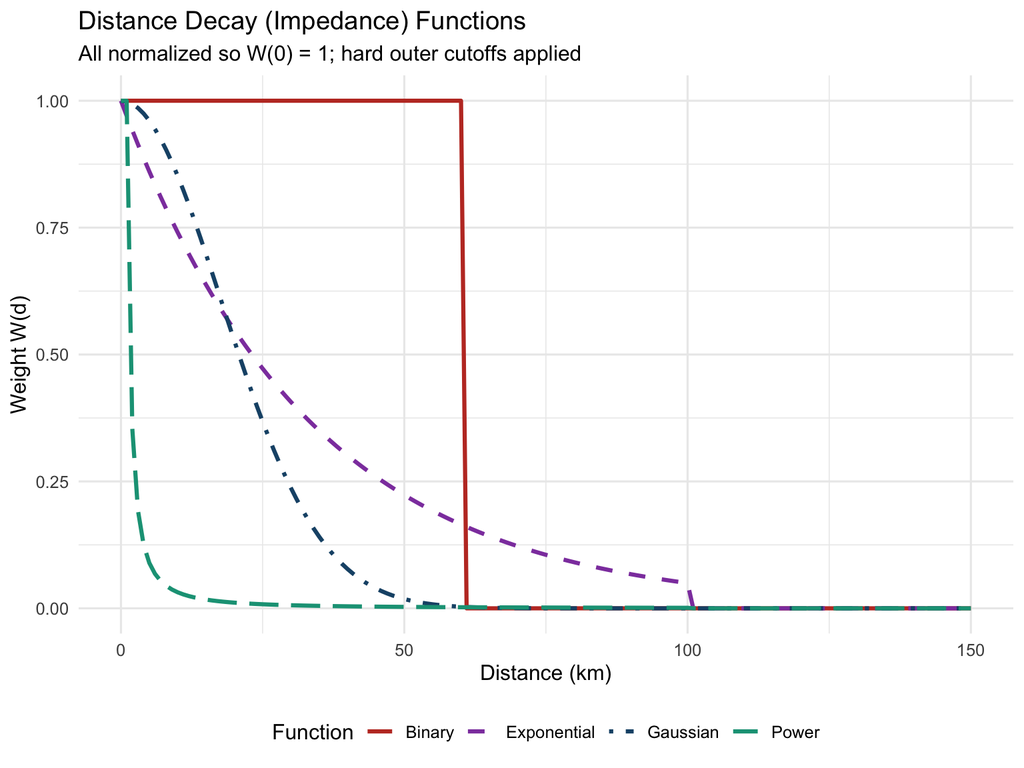

```r
d_seq <- seq(0, 150, by = 1)

decay_df <- data.frame(
  km          = d_seq,
  Binary      = as.numeric(d_seq <= 60),
  Gaussian    = ifelse(d_seq <= 100, exp(-(0.04 * d_seq)^2), 0),
  Exponential = ifelse(d_seq <= 100, exp(-0.03 * d_seq), 0),
  Power       = ifelse(d_seq > 0 & d_seq <= 100,
                       (d_seq / 1)^(-1.5) / 1,
                       ifelse(d_seq == 0, 1, 0))
) |>
  dplyr::mutate(Power = Power / max(Power, na.rm = TRUE)) |>   # normalize
  tidyr::pivot_longer(-km, names_to = "Function", values_to = "Weight")

ggplot(decay_df, aes(x = km, y = Weight, color = Function, linetype = Function)) +
  geom_line(linewidth = 1.1) +
  scale_color_manual(values = c("#c0392b", "#8e44ad", "#1a5276", "#16a085")) +
  scale_linetype_manual(values = c("solid", "dashed", "dotdash", "longdash")) +
  labs(
    title    = "Distance Decay (Impedance) Functions",
    subtitle = "All normalized so W(0) = 1; hard outer cutoffs applied",
    x = "Distance (km)", y = "Weight W(d)",
    color = "Function", linetype = "Function"
  ) +
  theme_minimal(base_size = 12) +
  theme(legend.position = "bottom")
```

### Implementation

```r
#' Two-Step Floating Catchment Area (2SFCA)
#'
#' @param demand   Numeric vector: demand (e.g., population) at each location
#' @param supply   Numeric vector: supply (e.g., beds) at each location
#' @param dist_mat Numeric matrix [n_demand × n_supply]: pairwise distances
#' @param d0       Numeric: catchment radius (same units as dist_mat)
#' @param decay_fn Function(d, d0, ...) returning weights in [0, 1]
#' @param ...      Additional arguments passed to decay_fn
#' @return         Numeric vector of accessibility scores (length = n_demand)
twosfca <- function(demand, supply, dist_mat, d0, decay_fn, ...) {

  n_demand <- length(demand)
  n_supply <- length(supply)

  # ── Step 1: provider-to-population ratios ──────────────────────────────────
  R <- numeric(n_supply)
  for (j in seq_len(n_supply)) {
    w_j   <- decay_fn(dist_mat[, j], d0, ...)
    denom <- sum(demand * w_j)
    R[j]  <- if (denom > 0) supply[j] / denom else 0
  }

  # ── Step 2: accessibility scores ───────────────────────────────────────────
  A <- numeric(n_demand)
  for (i in seq_len(n_demand)) {
    w_i  <- decay_fn(dist_mat[i, ], d0, ...)
    A[i] <- sum(R * w_i)
  }

  return(A)
}

# Decay function library
w_binary      <- function(d, d0)             as.numeric(d <= d0)
w_gaussian    <- function(d, d0, beta = 0.04){ w <- exp(-(beta*d)^2); w[d > d0] <- 0; w }
w_exponential <- function(d, d0, lam  = 0.03){ w <- exp(-lam*d);      w[d > d0] <- 0; w }
```

### Run the analysis

```r
# Distance matrix: county centroids → hospitals (km)
dist_m  <- st_distance(nc_centroids, hospitals_sf)
dist_km <- matrix(as.numeric(dist_m) / 1000,
                  nrow = nrow(nc_centroids),
                  ncol = nrow(hospitals_sf))

demand_vec <- nc_centroids$pop
supply_vec <- hospitals_sf$beds
D0 <- 100   # 100 km catchment radius

nc$access_binary  <- twosfca(demand_vec, supply_vec, dist_km, D0, w_binary)     * 1000
nc$access_gauss   <- twosfca(demand_vec, supply_vec, dist_km, D0, w_gaussian,  beta = 0.04) * 1000
nc$access_exp     <- twosfca(demand_vec, supply_vec, dist_km, D0, w_exponential, lam = 0.03) * 1000

cat("Summary of Gaussian 2SFCA scores (beds per 1,000 pop):\n")
```

```
Summary of Gaussian 2SFCA scores (beds per 1,000 pop):
```

```r
print(round(summary(nc$access_gauss), 5))
```

```
    Min.  1st Qu.   Median     Mean  3rd Qu.     Max.
 0.00000  0.00021  0.06920  2.27606  1.54698 24.83497
```

### Maps

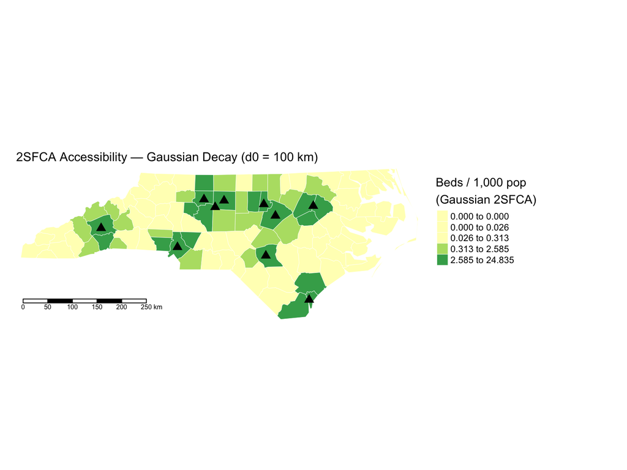

```r
tm_shape(nc) +
  tm_fill(
    col     = "access_gauss",
    style   = "quantile",
    n       = 5,
    palette = "RdYlGn",
    title   = "Beds / 1,000 pop\n(Gaussian 2SFCA)",
    legend.format = list(digits = 3)   # ← controls decimal places
  ) +
  tm_borders(col = "white", lwd = 0.4) +
  tm_shape(hospitals_sf) +
  tm_dots(col = "black", size = 0.4, shape = 17) +
  tm_layout(
    main.title      = "2SFCA Accessibility — Gaussian Decay (d0 = 100 km)",
    main.title.size = 0.95,
    legend.outside  = TRUE,
    frame = FALSE
  ) +
  tm_scale_bar(position = c("left", "bottom"))
```

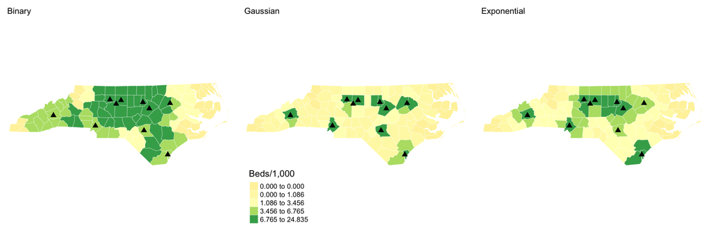

```r
# Shared breaks for a fair visual comparison across all three decay functions
all_vals     <- c(nc$access_binary, nc$access_gauss, nc$access_exp)
shared_breaks <- quantile(all_vals, probs = seq(0, 1, 0.2), na.rm = TRUE)

make_map <- function(col, title) {
  tm_shape(nc) +
    tm_fill(col = col, breaks = shared_breaks, palette = "RdYlGn",
            title = "Beds/1,000",
            legend.format = list(digits = 3),   # ← controls decimal places
            legend.show = (col == "access_gauss")) +
    tm_borders(col = "white", lwd = 0.3) +
    tm_shape(hospitals_sf) +
    tm_dots(col = "black", size = 0.25, shape = 17) +
    tm_layout(main.title = title, main.title.size = 0.85, frame = FALSE)
}

tmap_arrange(
  make_map("access_binary", "Binary"),
  make_map("access_gauss",  "Gaussian"),
  make_map("access_exp",    "Exponential"),
  ncol = 3
)
```

**Interpreting the Comparison**

The **binary** map produces sharp catchment boundaries — a county is either in or out. **Gaussian** and **exponential** functions produce smoother gradients. Notice that the geographic pattern of underservice (eastern NC) is consistent across all three — areas far from any major hospital. However, the *degree* of difference between well-served and underserved counties varies substantially, which matters when setting thresholds for policy interventions.

### Interactive map

```r
library(leaflet)

nc_wgs       <- st_transform(nc, 4326)
hospitals_wgs <- st_transform(hospitals_sf, 4326)

pal <- colorQuantile("RdYlGn", nc_wgs$access_gauss, n = 5)

leaflet(nc_wgs) |>
  addProviderTiles(providers$CartoDB.Positron) |>
  addPolygons(
    fillColor   = ~pal(access_gauss),
    fillOpacity = 0.75,
    color       = "white",
    weight      = 0.8,
    popup = ~paste0(
      "<b>", NAME, " County</b><br>",
      "Population proxy: <b>", format(round(pop), big.mark = ","), "</b><br>",
      "Gaussian 2SFCA: <b>", round(access_gauss, 5), " beds/1,000</b>"
    ),
    label = ~NAME
  ) |>
  addCircleMarkers(
    data        = hospitals_wgs,
    radius      = ~sqrt(beds / 10),
    fillColor   = "#c0392b",
    fillOpacity = 0.85,
    color       = "white",
    weight      = 1.5,
    popup       = ~paste0("<b>", name, "</b><br>Beds: <b>", beds, "</b>")
  ) |>
  addLegend(
    position = "bottomright",
    pal      = pal,
    values   = ~access_gauss,
    title    = "Access Quintile<br>(Gaussian 2SFCA)",
    opacity  = 0.9
  ) |>
  addScaleBar(position = "bottomleft")
```

[interactive chart not shown]

## Part 5 — Cumulative Opportunities with `r5r`

The `r5r` package enables **multimodal routing** (walk, bike, transit, car) over real OpenStreetMap and GTFS transport networks. The `accessibility()` function counts how many opportunities are reachable within a given travel time threshold — the **cumulative opportunities** measure.

**Why `r5r` Matters for Equity Analysis**

For populations dependent on public transit, Euclidean or driving-time distances dramatically **overestimate** accessibility. A hospital 5 km away may be 12 minutes by car but 75 minutes by bus. `r5r` captures this disparity — critical for equity framing.

The following code is illustrative — it requires a local GTFS feed and OSM `.pbf` file for your study area (download from download.geofabrik.de and your regional transit agency).

```r
# r5r requires: Java 11+, sufficient RAM, local OSM + GTFS files
options(java.parameters = "-Xmx4G")

library(r5r)
library(data.table)

data_path <- "path/to/your/r5r_data/"   # contains .osm.pbf + .zip (GTFS)
r5r_core  <- setup_r5(data_path)

# Origins: census tract centroids (data.frame with columns: id, lon, lat)
origins   <- fread("tract_centroids.csv")

# Destinations: hospital locations (must also have: id, lon, lat)
# Add a column for the "opportunity" count (1 per hospital location)
hospitals_r5         <- fread("hospitals.csv")
hospitals_r5$n_hosp  <- 1

# Routing parameters
mode               <- c("WALK", "TRANSIT")
max_walk_time      <- 20       # minutes
travel_time_cutoff <- 30       # count hospitals reachable in ≤ 30 min transit
departure_datetime <- as.POSIXct("2026-03-16 08:00:00")
time_window        <- 60       # average over a 60-minute departure window
percentiles        <- 50       # use median travel time estimate

access <- accessibility(
  r5r_core,
  origins                = origins,
  destinations           = hospitals_r5,
  mode                   = mode,
  opportunities_colnames = "n_hosp",
  decay_function         = "step",    # binary cumulative opportunities
  cutoffs                = travel_time_cutoff,
  departure_datetime     = departure_datetime,
  max_walk_time          = max_walk_time,
  time_window            = time_window,
  percentiles            = percentiles,
  progress               = TRUE
)

# Result: for each origin, how many hospitals reachable in ≤ 30 min by transit?
head(access)
#   id  opportunity  percentile  cutoff  accessibility
#   T01 n_hosp       50          30      2
#   T02 n_hosp       50          30      0   ← transit desert!

stop_r5(r5r_core)
```

### Comparing accessibility metrics: an illustration

The chart below shows how different methods can tell very different stories about the same set of locations.

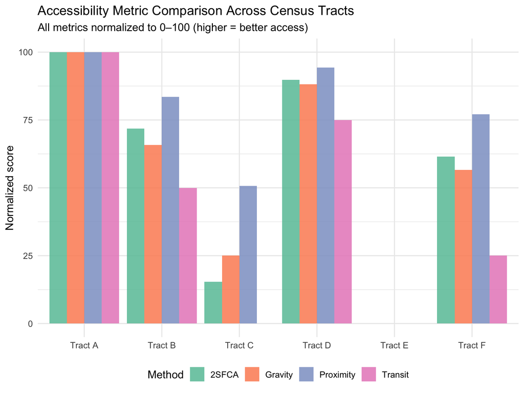

```r
comparison <- data.frame(
  Tract = paste("Tract", LETTERS[1:6]),
  Nearest_km          = c(1.2, 3.5, 8.1, 2.0, 15.2, 4.4),
  Gravity_score       = c(88,  62,  31,  79,   12,  55),
  SFCA_score          = c(0.42, 0.31, 0.09, 0.38, 0.03, 0.27),
  Transit_30min_count = c(4,    2,    0,    3,    0,    1)
)

norm <- function(x) (x - min(x)) / (max(x) - min(x)) * 100

comparison |>
  dplyr::mutate(
    Proximity = 100 - norm(Nearest_km),
    Gravity   = norm(Gravity_score),
    `2SFCA`   = norm(SFCA_score),
    Transit   = norm(Transit_30min_count)
  ) |>
  dplyr::select(Tract, Proximity, Gravity, `2SFCA`, Transit) |>
  tidyr::pivot_longer(-Tract, names_to = "Metric", values_to = "Score") |>
  ggplot(aes(x = Tract, y = Score, fill = Metric)) +
  geom_col(position = "dodge", alpha = 0.85) +
  scale_fill_brewer(palette = "Set2") +
  labs(
    title    = "Accessibility Metric Comparison Across Census Tracts",
    subtitle = "All metrics normalized to 0–100 (higher = better access)",
    x = NULL, y = "Normalized score", fill = "Method"
  ) +
  theme_minimal(base_size = 12) +
  theme(legend.position = "bottom")
```

## Part 6 — Sensitivity Analysis: The Modifiable Catchment Area Problem

The choice of catchment radius $d_0$ is one of the most consequential modeling decisions in 2SFCA — analogous to the **Modifiable Areal Unit Problem (MAUP)**.

The key is to use catchment sizes small enough that some counties genuinely fall **outside** all catchments at the smallest radius. With hospitals spaced ~100–200 km apart in rural NC, radii of 30–90 km produce very different coverage patterns.

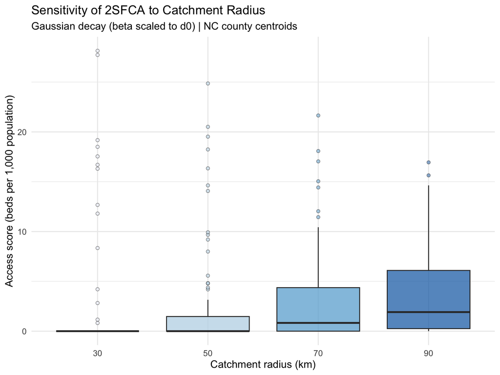

```r
# Use small-to-medium radii so the smallest catchment leaves rural counties
# genuinely uncovered. Scale beta to d0 so decay is meaningful at each radius.
catchment_sizes <- c(30, 50, 70, 90)

sens_df <- do.call(rbind, lapply(catchment_sizes, function(d0) {
  b <- 2 / d0   # scale beta so decay is meaningful relative to d0
  a <- twosfca(demand_vec, supply_vec, dist_km, d0, w_gaussian, beta = b)
  data.frame(
    CNTY_ID      = nc$CNTY_ID,
    NAME         = nc$NAME,
    catchment_km = d0,
    access_k     = a * 1000
  )
}))

ggplot(sens_df, aes(x = factor(catchment_km), y = access_k,
                    fill = factor(catchment_km))) +
  geom_boxplot(alpha = 0.75, outlier.shape = 21, outlier.alpha = 0.5) +
  scale_fill_brewer(palette = "Blues", name = "d0 (km)") +
  labs(
    title    = "Sensitivity of 2SFCA to Catchment Radius",
    subtitle = "Gaussian decay (beta scaled to d0) | NC county centroids",
    x = "Catchment radius (km)",
    y = "Access score (beds per 1,000 population)"
  ) +
  theme_minimal(base_size = 12) +
  theme(legend.position = "none")
```

The spread of scores increases sharply at small radii — rural counties that fall outside all catchments receive a score near zero, while peri-urban counties score very high. This is the signature of the MCAP.

```r
# How much does a county's RANK change between smallest and largest catchment?
rank_df <- sens_df |>
  dplyr::group_by(catchment_km) |>
  dplyr::mutate(rank = rank(-access_k, ties.method = "average")) |>
  dplyr::ungroup() |>
  dplyr::select(NAME, catchment_km, rank) |>
  tidyr::pivot_wider(names_from = catchment_km, values_from = rank,
                     names_prefix = "d") |>
  dplyr::mutate(rank_change = abs(d30 - d90)) |>
  dplyr::arrange(desc(rank_change))

cat("Counties with largest rank change between d0 = 30 km and d0 = 90 km:\n")
```

```
Counties with largest rank change between d0 = 30 km and d0 = 90 km:
```

```r
print(head(rank_df[, c("NAME", "d30", "d90", "rank_change")], 10))
```

```
# A tibble: 10 × 4
   NAME        d30   d90 rank_change
   <chr>     <dbl> <dbl>       <dbl>
 1 Brunswick  57.5     7        50.5
 2 Pender     57.5     9        48.5
 3 Alamance   57.5    12        45.5
 4 Franklin   57.5    13        44.5
 5 Stokes     57.5    15        42.5
 6 Harnett    57.5    16        41.5
 7 Chatham    57.5    18        39.5
 8 Randolph   57.5    19        38.5
 9 Davie      57.5    20        37.5
10 Cabarrus   57.5    21        36.5
```

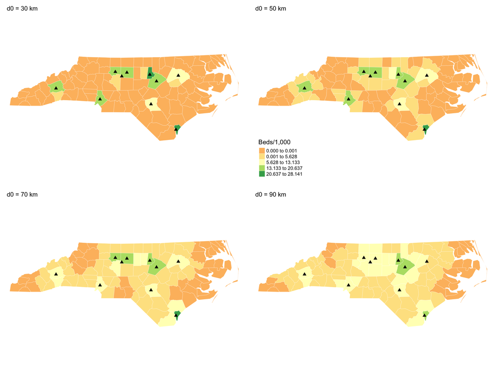

```r
for (d0 in catchment_sizes) {
  nc[[paste0("acc_", d0)]] <- sens_df$access_k[sens_df$catchment_km == d0]
}

# FIXED breaks (not quantile) so maps are directly comparable across panels.
# Zeros / near-zeros will appear red — the whole point of the demonstration.
global_max <- max(sapply(catchment_sizes,
                         function(d0) max(nc[[paste0("acc_", d0)]], na.rm = TRUE)))
fixed_breaks <- c(0, 0.001,
                  seq(global_max * 0.2, global_max, length.out = 4))

sm <- lapply(catchment_sizes, function(d0) {
  col <- paste0("acc_", d0)
  tm_shape(nc) +
    tm_fill(col    = col,
            breaks = fixed_breaks,
            palette = "RdYlGn",
            title  = "Beds/1,000",
            legend.show = (d0 == 50)) +
    tm_borders(col = "white", lwd = 0.3) +
    tm_shape(hospitals_sf) +
    tm_dots(col = "black", size = 0.2, shape = 17) +
    tm_layout(main.title      = paste0("d0 = ", d0, " km"),
              main.title.size = 0.9, frame = FALSE)
})

tmap_arrange(sm[[1]], sm[[2]], sm[[3]], sm[[4]], ncol = 2, nrow = 2)
```

**The Modifiable Catchment Area Problem (MCAP)**

With **fixed color breaks** (same scale across all panels), the contrast is clear: at $d_0 = 30$ km many eastern and rural counties are completely unserved (red); by $d_0 = 90$ km nearly all counties access at least some supply. The rank-change table above identifies which counties *flip most* in their relative standing — these are the areas where sensitivity reporting is most critical in any published study.

## Part 7 — Equity Framing

Accessibility analysis gains its public health significance when linked to an equity frame: **who** lives in underserved areas, and do they face compounding disadvantages?

```r
# Flag underserved: bottom quintile of Gaussian 2SFCA
q20 <- quantile(nc$access_gauss, probs = 0.20, na.rm = TRUE)
nc$underserved <- nc$access_gauss <= q20

cat("Underserved counties:", sum(nc$underserved), "of", nrow(nc), "\n")
```

```
Underserved counties: 20 of 100
```

```r
cat("Population in underserved counties:",
    format(sum(nc$pop[nc$underserved]), big.mark = ","),
    sprintf("(%.1f%% of total)\n",
            100 * sum(nc$pop[nc$underserved]) / sum(nc$pop)))
```

```
Population in underserved counties: 53,588 (7.1% of total)
```

```r
# In a real analysis you would merge ACS data here:
# - % below poverty line
# - % without vehicle access
# - % aged 65+
# - % uninsured

nc |>
  st_drop_geometry() |>
  dplyr::filter(underserved) |>
  dplyr::select(NAME, pop, access_gauss) |>
  dplyr::arrange(access_gauss) |>
  dplyr::mutate(
    pop         = format(round(pop), big.mark = ","),
    access_gauss = round(access_gauss, 5)
  ) |>
  head(10) |>
  knitr::kable(
    col.names = c("County", "Pop. proxy", "Gaussian 2SFCA score"),
    caption   = "Ten least-accessible counties (bottom quintile, Gaussian 2SFCA)"
  )
```

Ten least-accessible counties (bottom quintile, Gaussian 2SFCA)

| County | Pop. proxy | Gaussian 2SFCA score |
| --- | --- | --- |
| Ashe | 2,455 | 0 |
| Currituck | 1,338 | 0 |
| Camden | 636 | 0 |
| Gates | 1,014 | 0 |
| Pasquotank | 3,913 | 0 |
| Watauga | 3,098 | 0 |
| Perquimans | 1,160 | 0 |
| Chowan | 1,650 | 0 |
| Caldwell | 7,858 | 0 |
| Washington | 2,131 | 0 |

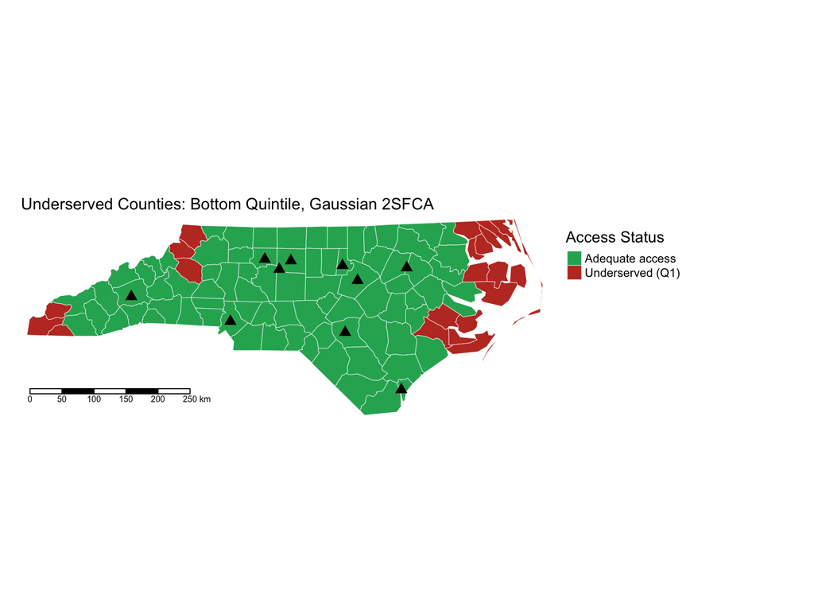

```r
nc$access_label <- ifelse(nc$underserved, "Underserved (Q1)", "Adequate access")

tm_shape(nc) +
  tm_fill(
    col     = "access_label",
    palette = c("Adequate access" = "#27ae60", "Underserved (Q1)" = "#c0392b"),
    title   = "Access Status"
  ) +
  tm_borders(col = "white", lwd = 0.4) +
  tm_shape(hospitals_sf) +
  tm_dots(col = "black", size = 0.35, shape = 17) +
  tm_layout(
    main.title = "Underserved Counties: Bottom Quintile, Gaussian 2SFCA",
    main.title.size = 0.95,
    legend.outside = TRUE,
    frame = FALSE
  ) +
  tm_scale_bar(position = c("left", "bottom"))
```

## Summary

We introduced a spectrum of spatial accessibility methods — from simple proximity through gravity models to the 2SFCA. Key takeaways:

- **No single method is universally best.** Gravity models capture cumulative access; 2SFCA adds competition effects; `r5r` captures mode-specific realism essential for transit equity studies.
- **Distance decay assumptions are consequential.** Binary, Gaussian, and exponential functions can change which areas appear underserved.
- **The Modifiable Catchment Area Problem** demands sensitivity analysis — it is not optional.
- **Travel time ≠ straight-line distance**, especially for transit-dependent populations. Ignoring mode effects systematically underestimates barriers for vulnerable groups.
- **Equity framing** links spatial patterns to populations — accessibility analysis is most powerful when it answers *who* is underserved, not just *where*.

## References

- Luo, W., & Wang, F. (2003). Measures of spatial accessibility to health care in a GIS environment. *Environment and Planning B*, 30(6), 865–884.
- Luo, W., & Qi, Y. (2009). An enhanced two-step floating catchment area (E2SFCA) method. *Health & Place*, 15(4), 1100–1107.
- Stewart, J. Q. (1942). Measure of the influence of a population at a distance. *Sociometry*, 5(1), 63–71.
- Reilly, W. J. (1931). *The Law of Retail Gravitation*. W. J. Reilly.
- Huff, D. (1964). Defining and estimating a trading area. *Journal of Marketing*, 28, 34–38.
- Commenges, H., & Giraud, T. (2023). *SpatialPosition: Spatial Position Models*. R package.
- Saraiva, M., Pereira, R., et al. (2023). *r5r: Rapid Realistic Routing with R5 in R*. R package. Vignette adapted by Eric Delmelle.
- Apparicio, P., et al. (2008). Comparing alternative approaches to measuring geographical accessibility. *International Journal of Health Geographics*, 7(1), 7.

*Spatial Epidemiology | Lehigh University | Spring 2026 | Eric Delmelle*